# time_series

Edzer Pebesma

October 16, 2017

```r
library(gstat)
data(wind)
ls()
```

```
## [1] "wind"     "wind.loc"
```

```r
head(wind)
```

```
##   year month day   RPT   VAL   ROS   KIL   SHA  BIR   DUB   CLA   MUL
## 1   61     1   1 15.04 14.96 13.17  9.29 13.96 9.87 13.67 10.25 10.83
## 2   61     1   2 14.71 16.88 10.83  6.50 12.62 7.67 11.50 10.04  9.79
## 3   61     1   3 18.50 16.88 12.33 10.13 11.17 6.17 11.25  8.04  8.50
## 4   61     1   4 10.58  6.63 11.75  4.58  4.54 2.88  8.63  1.79  5.83
## 5   61     1   5 13.33 13.25 11.42  6.17 10.71 8.21 11.92  6.54 10.92
## 6   61     1   6 13.21  8.12  9.96  6.67  5.37 4.50 10.67  4.42  7.17
##     CLO   BEL   MAL
## 1 12.58 18.50 15.04
## 2  9.67 17.54 13.83
## 3  7.67 12.75 12.71
## 4  5.88  5.46 10.88
## 5 10.34 12.92 11.83
## 6  7.50  8.12 13.17
```

```r
head(wind.loc)
```

```
##         Station Code Latitude Longitude MeanWind
## 1      Valentia  VAL  51d56'N   10d15'W     5.48
## 2     Belmullet  BEL  54d14'N   10d00'W     6.75
## 3   Claremorris  CLA  53d43'N    8d59'W     4.32
## 4       Shannon  SHA  52d42'N    8d55'W     5.38
## 5 Roche's Point  RPT  51d48'N    8d15'W     6.36
## 6          Birr  BIR  53d05'N    7d53'W     3.65
```

Let’s take a single vector out of the `wind` dataset, and plot it

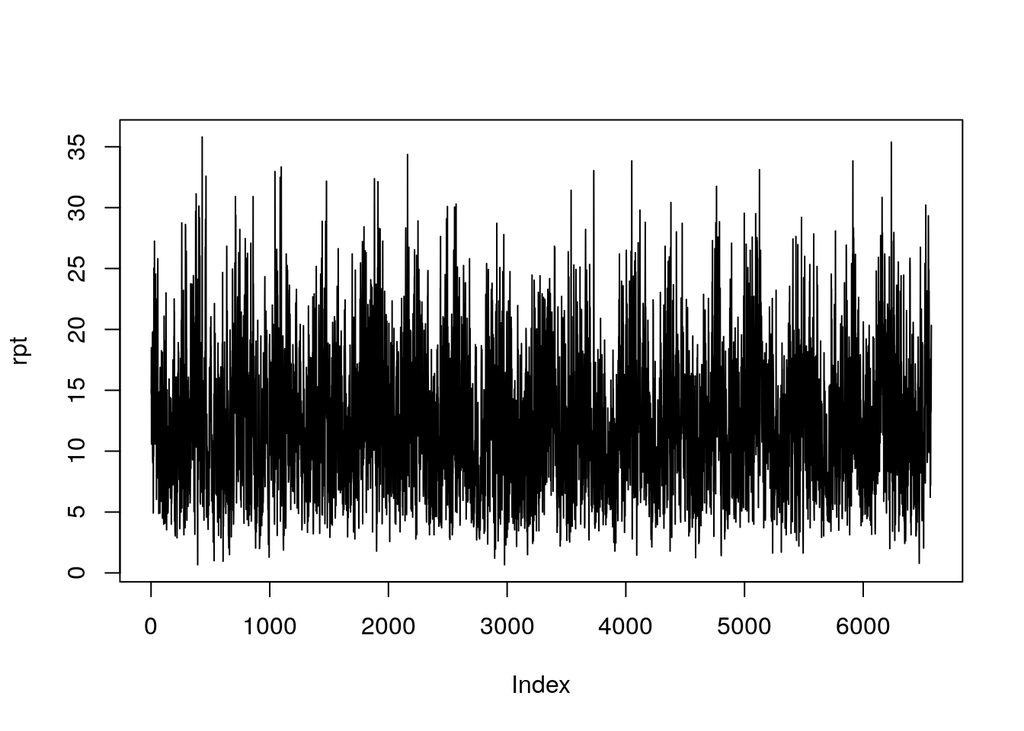

```r
rpt = wind$RPT
plot(rpt, type = 'l')
```

We now see that the x-axis is not meaningfully referenced (index: 1,2,…,n); we can do better by defining a `ts` object:

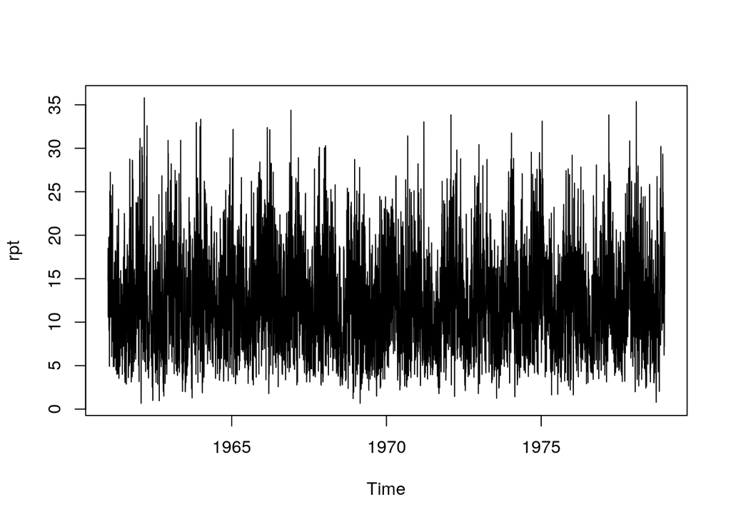

```r
rpt = ts(wind$RPT, start = 1961, frequency = 365.25)
plot(rpt)
```

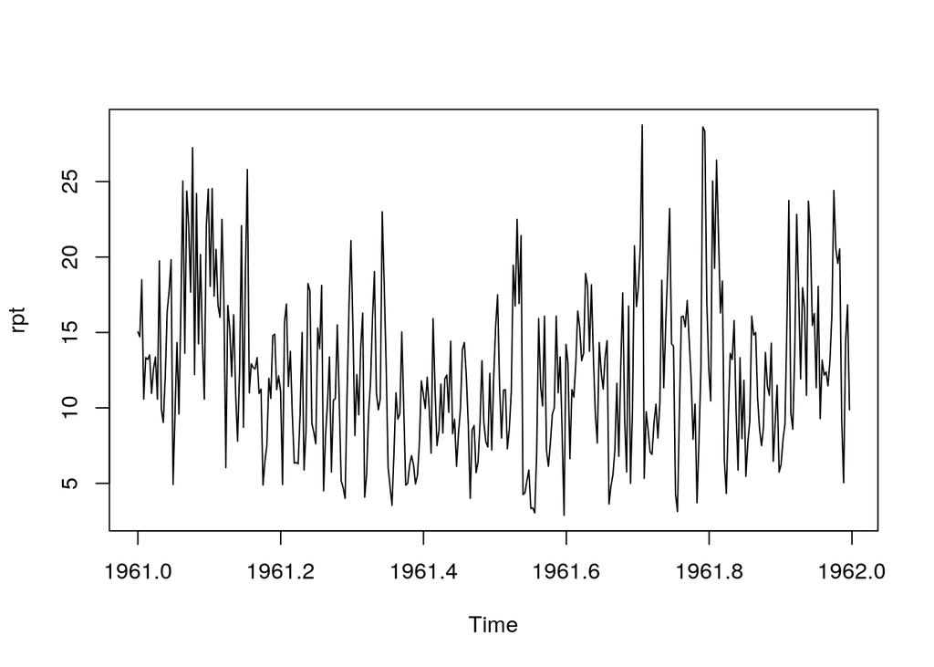

```r
rpt = ts(wind$RPT[1:365], start = 1961, frequency = 365.25)
plot(rpt)
```

## time classes

We can see (from the last plot) that R has no real understanding what the time stands for; we defined it here simply as decimal years, but didn’t specify this anywhere.

R has two native classes for time: `Date` and `POSIXct`:

```r
(t0 = Sys.time())
```

```
## [1] "2018-11-04 21:02:20 CET"
```

```r
class(t0)
```

```
## [1] "POSIXct" "POSIXt"
```

```r
(d0 = Sys.Date())
```

```
## [1] "2018-11-04"
```

```r
class(d0)
```

```
## [1] "Date"
```

both of which are numeric vectors with a class attribute, where the class attribute points out how the number should be understood, either seconds since 1970-01-01 00:00 GMT

```r
as.numeric(Sys.time())
```

```
## [1] 1541361740
```

or days since that date

```r
as.numeric(Sys.Date())
```

```
## [1] 17839
```

## Reading in date or time

We can make time-aware time series objects using packages `zoo` or `xts`:

```r
library(xts)
index = paste(1900 + wind$year, wind$month, wind$day, sep = "-")
index[1:3]
```

```
## [1] "1961-1-1" "1961-1-2" "1961-1-3"
```

```r
index.date = as.Date(index)
index.date[1:3]
```

```
## [1] "1961-01-01" "1961-01-02" "1961-01-03"
```

```r
as.numeric(index.date[1:3])
```

```
## [1] -3287 -3286 -3285
```

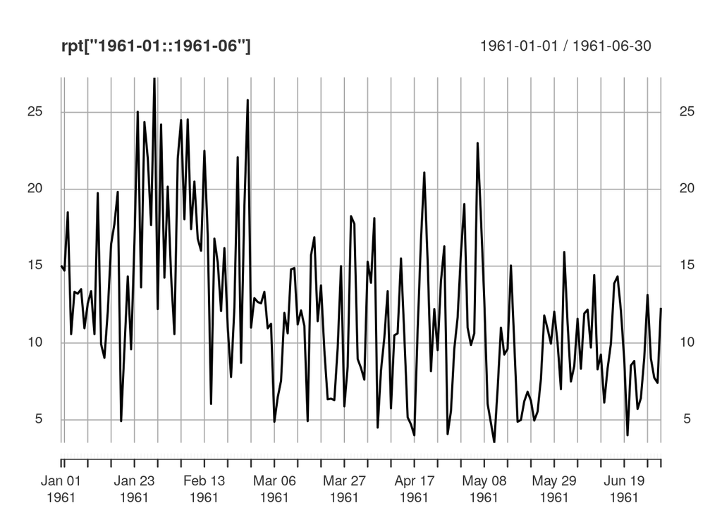

```r
rpt = xts(wind$RPT, index.date)
plot(rpt["1961-01::1961-06"])
```

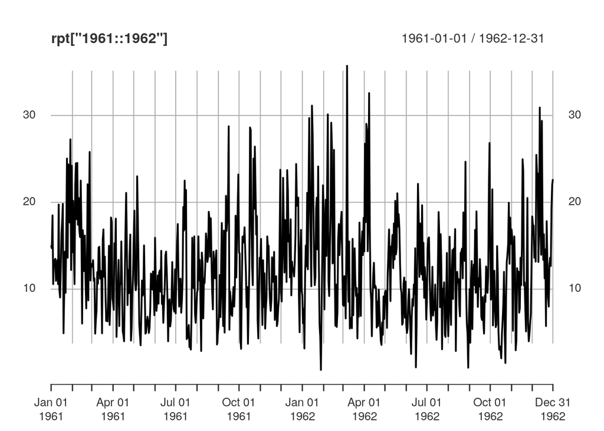

```r
plot(rpt["1961::1962"])
```

## Autocorrelation

The question whether time series are autocorrelated boils down to whether, for a given time series, the first $n-p$ observations are correlated with the last $n-p$, where $p$ is called the *lag*. We can compute this, by hand, e.g. for the wind data at NRP and lags 1 and 2 by

```r
n = length(wind$RPT)
cor(head(wind$RPT, n), tail(wind$RPT, n)) # obviously!
```

```
## [1] 1
```

```r
n = length(wind$RPT) - 1
cor(head(wind$RPT, n), tail(wind$RPT, n))
```

```
## [1] 0.4879959
```

```r
n = length(wind$RPT) - 2
cor(head(wind$RPT, n), tail(wind$RPT, n))
```

```
## [1] 0.2471285
```

```r
a = acf(wind$RPT, plot = FALSE)
a$acf[1:3]
```

```
## [1] 1.0000000 0.4879129 0.2470608
```

and the possibility to plot the autocorrelations:

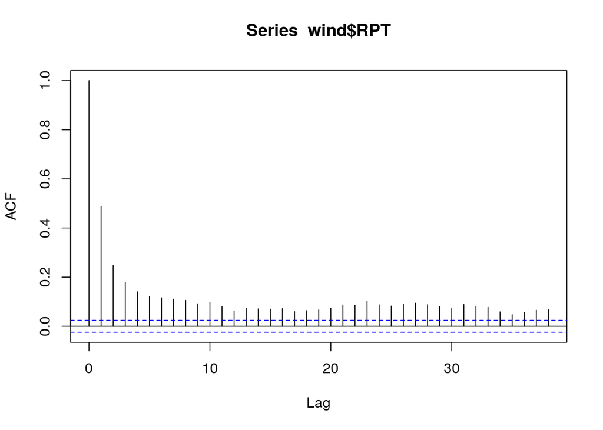

```r
plot(a)
```

We can plot autocorrelations up to larger lags by

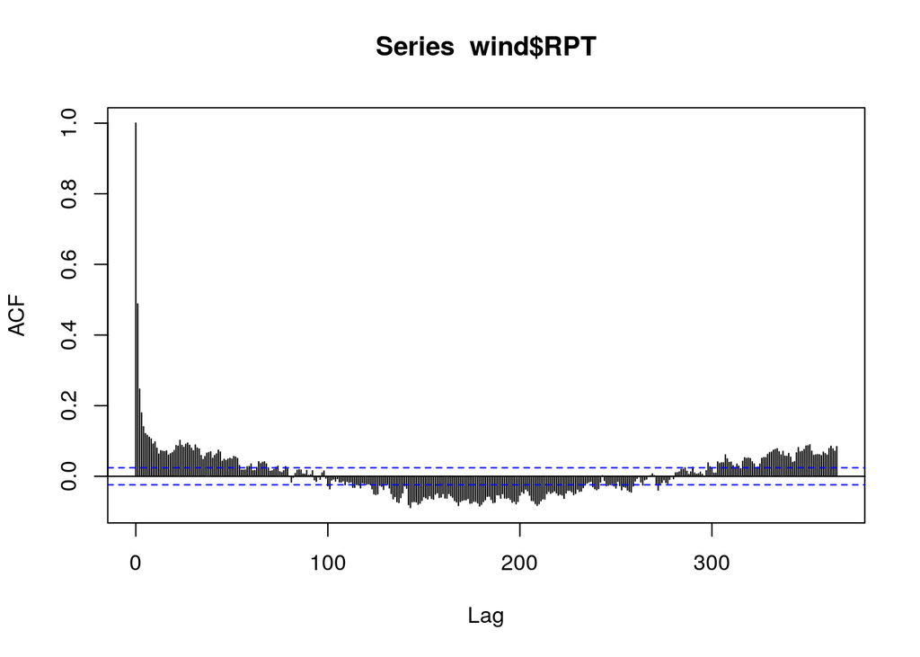

```r
plot(acf(wind$RPT, lag.max = 365))
```

Can you explain the negative autocorrelations around lag 180, and positive ones around 360?

## AR(n) processes; generating them

An AR(1) process is defined as $y(t) = \phi_1 y(t-1) + e(t)$ with $phi_1$ the AR(1) coefficient (between 0 and 1), and $e(t)$ independent, normal, random variable.

We can generate an AR(1) by hand by

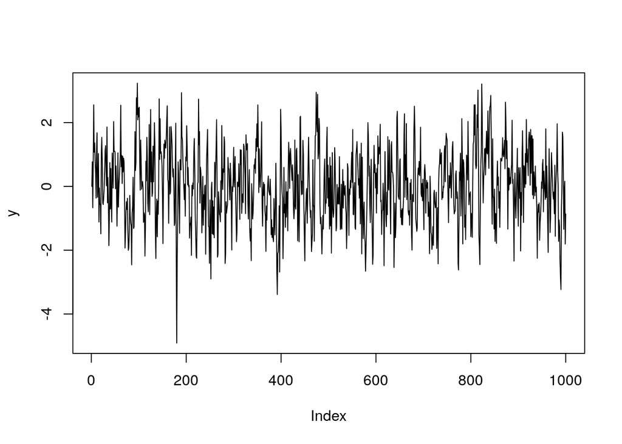

```r
n = 1000
phi = 0.5
y = vector("numeric", n)
y[1] = 0
for (i in 2:n)
    y[i] = phi[1] * y[i-1] + rnorm(1)
plot(y, type = 'l')
```

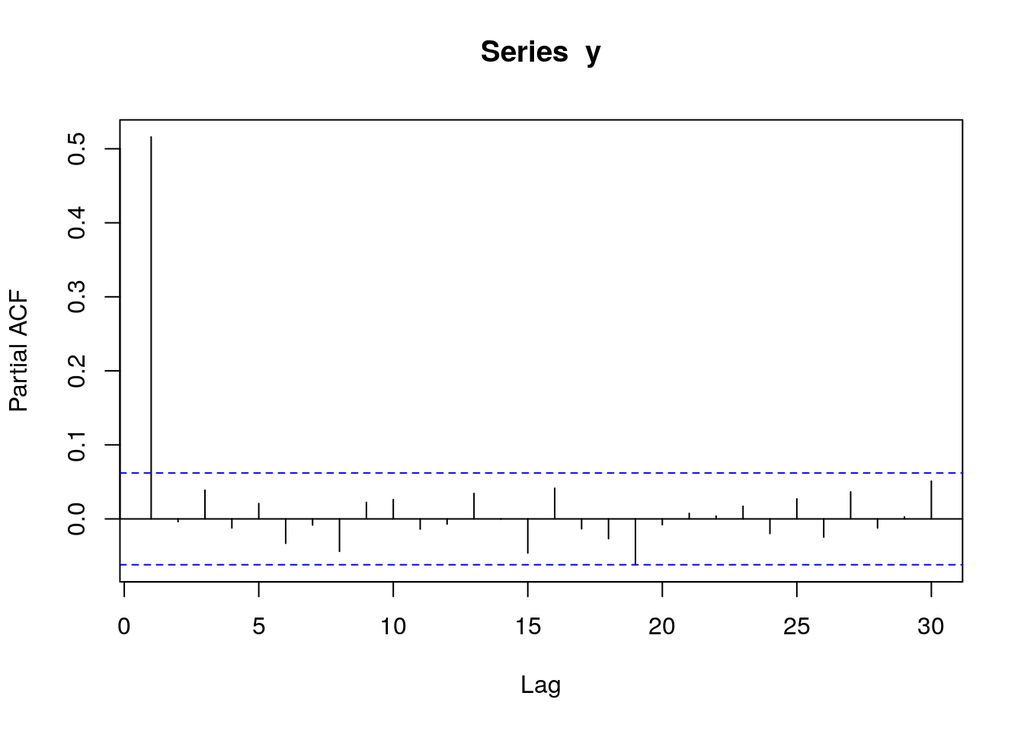

```r
pacf(y)
```

For higher-order AR(n) processes, we have $y(t) = \sum_{j=1}^p \phi_j y(t-j) + e(t)$ with $\phi_j = (\phi_1,...,\phi_p)$ the $p$ AR coefficient (between 0 and 1, with additional constraints for $y$ to be stationary), and $e(t)$ independent, normal, random variable.

Although it would be quite easy to modify the code above, it is easier to use `arima.sim` to simulate a particular process, e.g. by

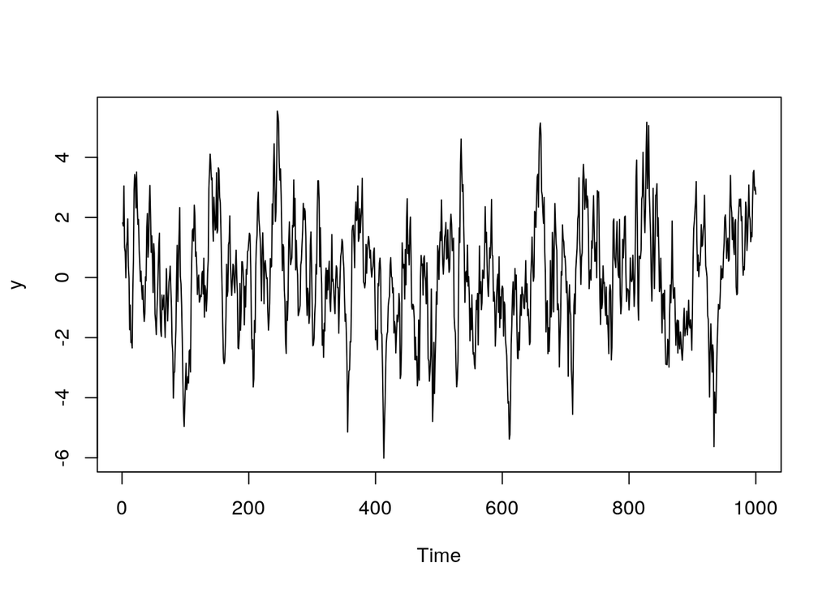

```r
y = arima.sim(model = list(ar = c(0.9, -0.1)), n = 1000)
plot(y, type = 'l')
```

Although such series are autocorrelated up to high lags

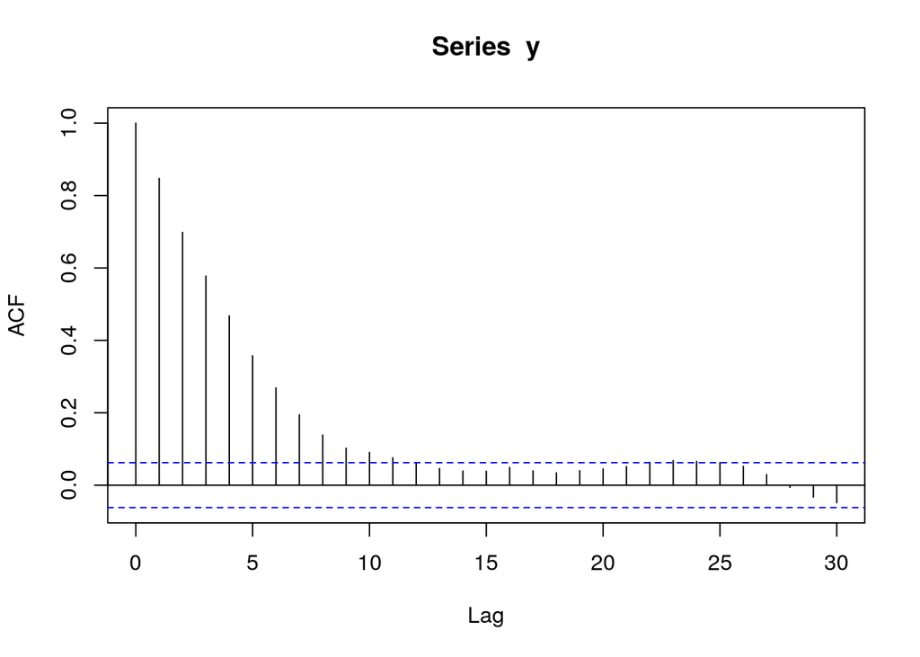

```r
acf(y)
```

it is their *partial* autocorrelatoin coefficients that reveal their generating model:

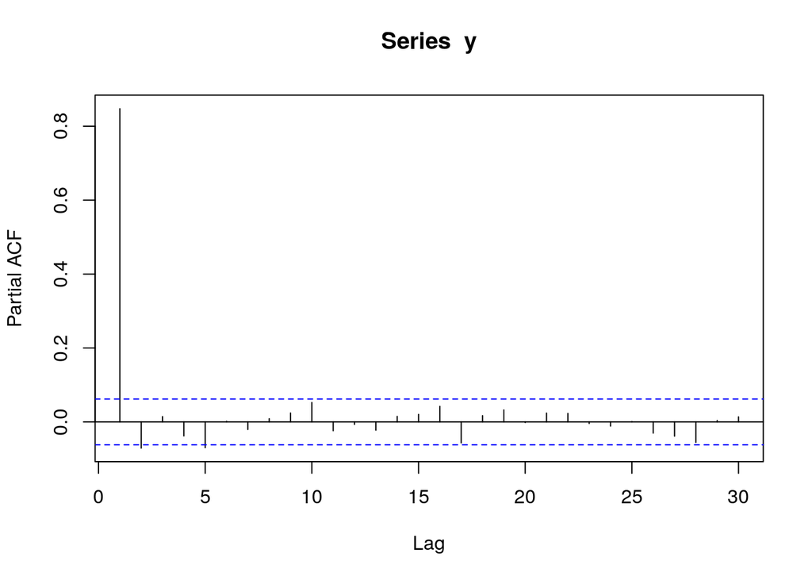

```r
pacf(y)
```

Partial autocorrelation at lag $p$ ($p > 1$) can be thought of as the autocorrelation between the first $n-p$ and the last $n-p$ observations *after correcting for all correlations occuring at shorter lags*.

## ARIMA models

ARIMA models are a very generic class for (linear) time domain analysis. They contain an AR(p) and MA(q) component, and work on $d$ times differenced series:

$\mbox{Diff}^d (y(t)) = \sum_{j=1}^p \phi_j y(t-j) + \sum_{k=1}^q \alpha_k e(t-k)$

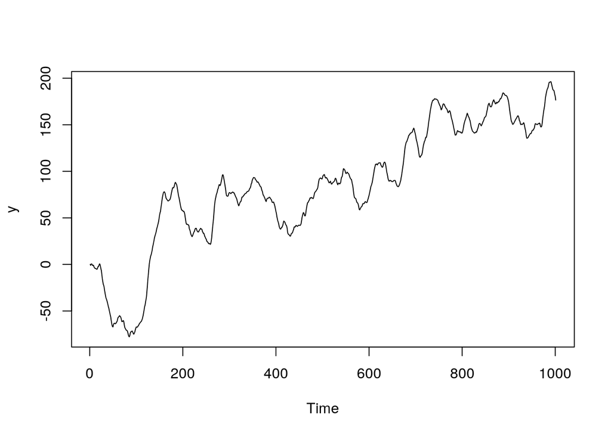

```r
set.seed(139)
y = arima.sim(model = list(ar = c(0.9, -0.1), order = c(2, 1, 0)), n = 1000)
plot(y, type = 'l')
```

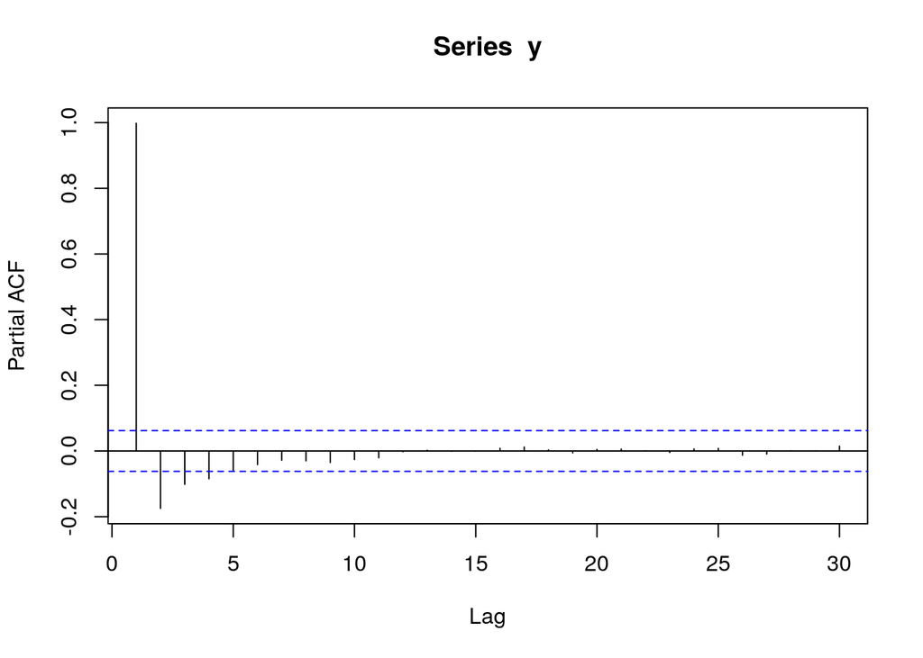

```r
plot(pacf(y))
```

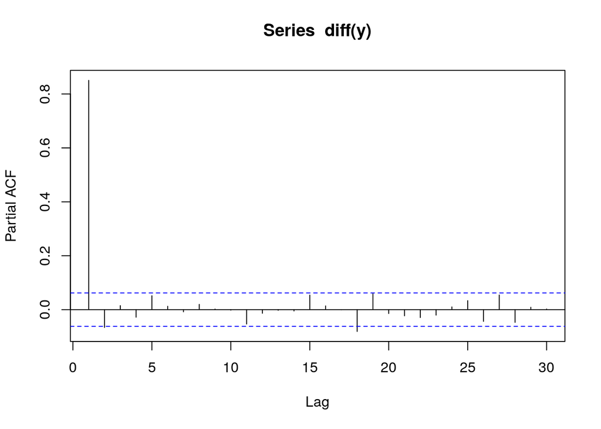

```r
plot(pacf(diff(y)))
```

## Exercises thursday:

1. find two time series data sets, of length more than 50
2. Read them in R
3. find a suitable ARIMA model that fits these data